# Predicting Machine Failures - A look at Imbalanced Classification

### *June 2024, Pavlo Mysak*

In this project, we explore the task of predicting machine failures using data from the following Kaggle competition: [https://www.kaggle.com/competitions/playground-series-s3e17/data].

The primary objective of this challenge is to predict instances of machine failures from a given dataset, highlighting the intricacies involved in imbalanced classification problems.

Imbalanced classification is a common scenario in various industry applications where the number of instances of one class significantly outnumbers the instances of the other class. This issue is prevalent in fields such as fraud detection, customer churn prediction, and medical diagnosis, where the minority class often represents the critical cases we aim to identify. In this context, machine failures are the minority class that we seek to predict accurately amidst a large volume of non-failure data.

For this analysis, we will utilize powerful Python libraries, including Pandas for data manipulation, Scikit-Learn for building and evaluating machine learning models, and IMB-Learn for handling imbalanced datasets through techniques like SMOTE (Synthetic Minority Over-sampling Technique).

Imbalanced classification problems present unique challenges. Achieving great model results can be difficult due to the skewed class distribution. Moreover, the performance metrics and model evaluation often depend heavily on the business use-case. In some scenarios, having a high precision (minimizing false positives) is paramount, such as in fraud detection, where incorrectly flagging a legitimate transaction can have adverse effects. Conversely, in cases like disease screening, recall (minimizing false negatives) might be more critical, as missing a true positive can have severe consequences.

Through this project, we aim to explore various models and techniques to address the imbalanced classification challenge in predicting machine failures. We will investigate the performance of different algorithms, both with and without the application of SMOTE, to understand their strengths and limitations in this context. By presenting a comprehensive analysis, we hope to provide valuable insights into effectively handling imbalanced datasets and making informed decisions based on the specific requirements of the use-case.

## Background and Motivation

Machine failures can have significant impacts on businesses, including downtime, increased maintenance costs, and potential safety hazards. Predicting these failures before they occur can help in proactive maintenance and prevent costly disruptions. This problem is particularly relevant in industries such as manufacturing, aviation, and data centers, where machine reliability is critical.

## Methodology

### Data Preprocessing:

> - Cleaning and preparing the data for analysis.
> - Identifying distributions and relationships present in the data.

### Feature Engineering:

> - Creating and selecting features that improve model performance.

### Handling Imbalanced Data:

> - Implimenting Algorithm-Level appraoches such as cost-sensitive learning.
> - Implimenting Data-Level approaches such as oversampling (specifically SMOTE).

### Model Building:

> - Developing several machine learning classifiers, including Decision Trees, AdaBoost, and HGBoost.
> - Utilizing Stratified K-Fold Cross Validation to ensure that each fold has the same proportion of class labels as the original dataset.

### Model Evaluation:

> - Evaluating models using metrics such as F1 Score, ROC AUC, Precision and Recall.
> - Comparing SMOTE-based models and Cost-Sensitive-Learning-based models.
> - Discussing differences in evaluation with business-case in mind.
> - Tuning a classifiers' decision thresholds in regard to the optimization of specific evaluation metrics.

### Let's dig in!!

```python
import numpy as np
import pandas as pd
import matplotlib.pyplot as plt

# sklearn and imblearn
from sklearn.model_selection import train_test_split, StratifiedKFold, RandomizedSearchCV
from sklearn.pipeline import make_pipeline
from sklearn.compose import ColumnTransformer
from sklearn.preprocessing import StandardScaler, OneHotEncoder, FunctionTransformer
from sklearn.metrics import recall_score, precision_score, f1_score, roc_auc_score, confusion_matrix, ConfusionMatrixDisplay
from imblearn.pipeline import Pipeline
from imblearn.over_sampling import SMOTE

# sklearn models
from sklearn.tree import DecisionTreeClassifier
from sklearn.ensemble import AdaBoostClassifier, HistGradientBoostingClassifier

# Filter out warning messages
import warnings
```

```python
dt = pd.read_csv('/Users/pavlomysak/playground-series-s3e17/train.csv')

dt.info()
```

```
<class 'pandas.core.frame.DataFrame'>
RangeIndex: 136429 entries, 0 to 136428
Data columns (total 14 columns):
 #   Column                   Non-Null Count   Dtype
---  ------                   --------------   -----
 0   id                       136429 non-null  int64
 1   Product ID               136429 non-null  object
 2   Type                     136429 non-null  object
 3   Air temperature [K]      136429 non-null  float64
 4   Process temperature [K]  136429 non-null  float64
 5   Rotational speed [rpm]   136429 non-null  int64
 6   Torque [Nm]              136429 non-null  float64
 7   Tool wear [min]          136429 non-null  int64
 8   Machine failure          136429 non-null  int64
 9   TWF                      136429 non-null  int64
 10  HDF                      136429 non-null  int64
 11  PWF                      136429 non-null  int64
 12  OSF                      136429 non-null  int64
 13  RNF                      136429 non-null  int64
dtypes: float64(3), int64(9), object(2)
memory usage: 14.6+ MB
```

```python
dt.head()
```

|  | id | Product ID | Type | Air temperature [K] | Process temperature [K] | Rotational speed [rpm] | Torque [Nm] | Tool wear [min] | Machine failure | TWF | HDF | PWF | OSF | RNF |
| --- | --- | --- | --- | --- | --- | --- | --- | --- | --- | --- | --- | --- | --- | --- |
| 0 | 0 | L50096 | L | 300.6 | 309.6 | 1596 | 36.1 | 140 | 0 | 0 | 0 | 0 | 0 | 0 |
| 1 | 1 | M20343 | M | 302.6 | 312.1 | 1759 | 29.1 | 200 | 0 | 0 | 0 | 0 | 0 | 0 |
| 2 | 2 | L49454 | L | 299.3 | 308.5 | 1805 | 26.5 | 25 | 0 | 0 | 0 | 0 | 0 | 0 |
| 3 | 3 | L53355 | L | 301.0 | 310.9 | 1524 | 44.3 | 197 | 0 | 0 | 0 | 0 | 0 | 0 |
| 4 | 4 | M24050 | M | 298.0 | 309.0 | 1641 | 35.4 | 34 | 0 | 0 | 0 | 0 | 0 | 0 |

```python
# A look at the class imbalance
dt['Machine failure'].value_counts(normalize=True)
```

```
0    0.984256
1    0.015744
Name: Machine failure, dtype: float64
```

# Notes on Next Steps:

We see that we have 14 features with 136,429 observations in the original data. Only 1.6% of observations depict a machine failure (the positive case). When creating our training and testing sets, we should split the data in a stratified fashion to ensure that we have a comparable number of positive cases in both of the sets.

```python
# Creating our Train/Test splits with stratification
X_train, X_test, y_train, y_test = train_test_split(dt.drop('Machine failure', axis = 1),
                                                    dt['Machine failure'],
                                                    test_size=0.3,
                                                    stratify=(dt['Machine failure']))
```

# Numeric Data Overview

```
array([[<Axes: title={'center': 'id'}>,
        <Axes: title={'center': 'Air temperature [K]'}>,
        <Axes: title={'center': 'Process temperature [K]'}>],
       [<Axes: title={'center': 'Rotational speed [rpm]'}>,
        <Axes: title={'center': 'Torque [Nm]'}>,
        <Axes: title={'center': 'Tool wear [min]'}>],
       [<Axes: title={'center': 'TWF'}>, <Axes: title={'center': 'HDF'}>,
        <Axes: title={'center': 'PWF'}>],
       [<Axes: title={'center': 'OSF'}>, <Axes: title={'center': 'RNF'}>,
        <Axes: >]], dtype=object)
```

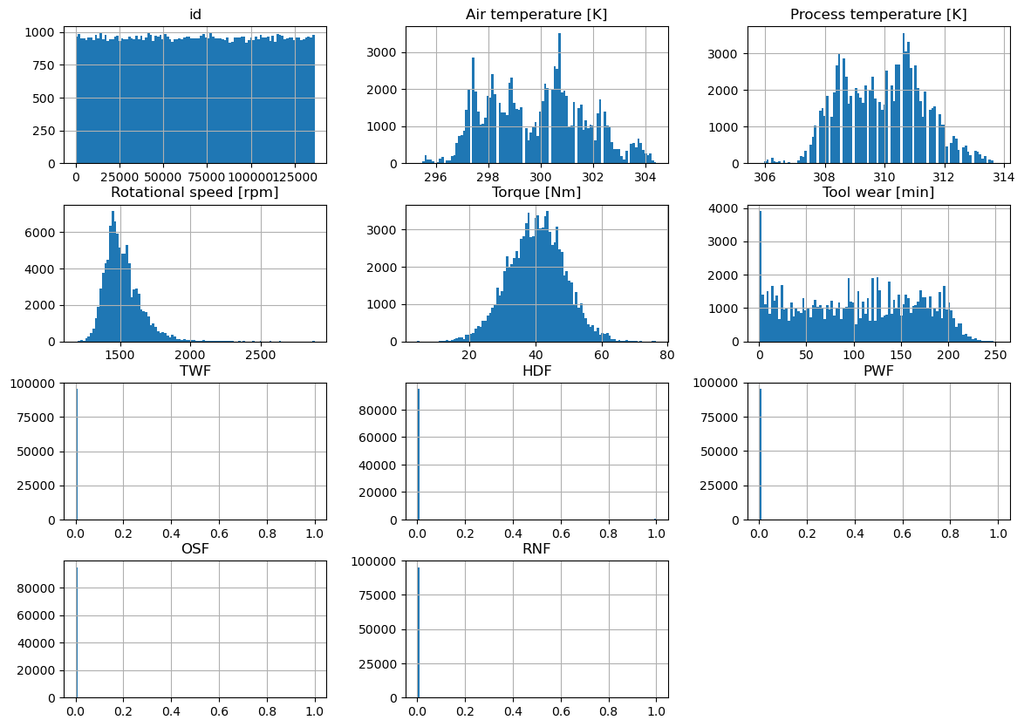

```python
# Creating histograms of our data
X_train.hist(figsize=(14,10), bins = 100)
```